# iNeuron Logistic Regression on Algerian Forest Fire Task

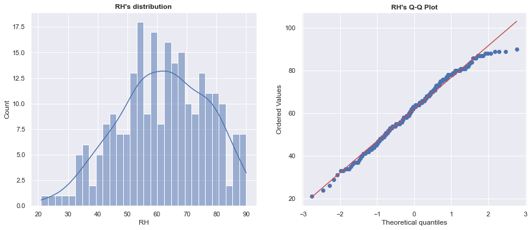

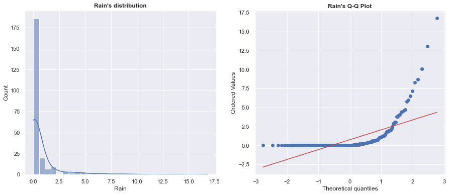

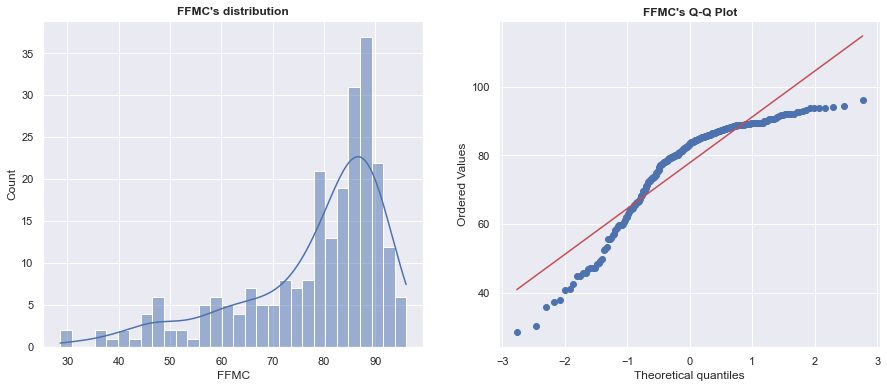

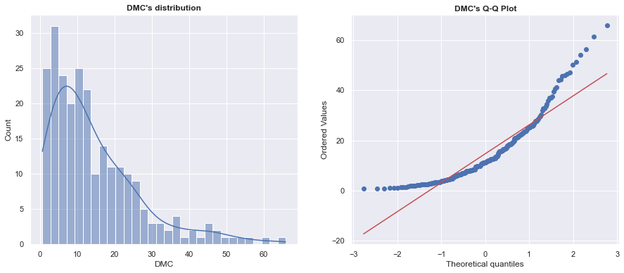

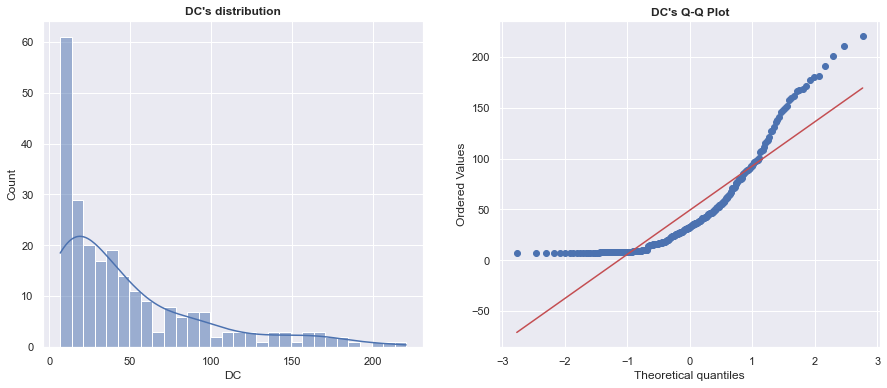

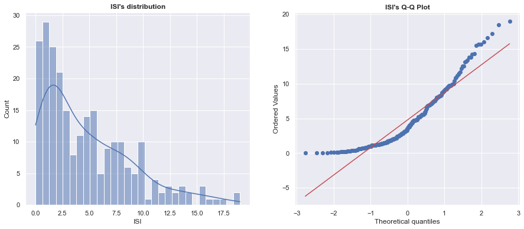

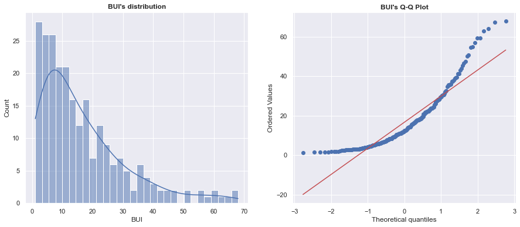

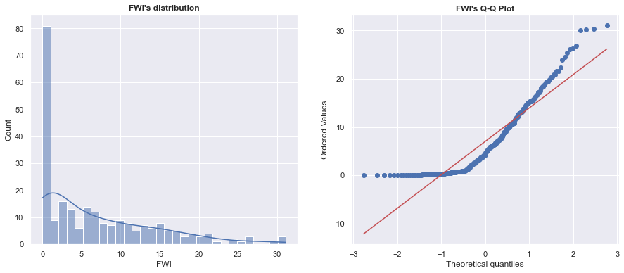

```python
for i in continuous_features:
    plt.figure(figsize= (15,6))
    plt.subplot(121)
    sns.histplot(data= df, x= i, kde= True, bins= 30)
    plt.title("{}'s distribution".format(i), fontweight= "bold")

    plt.subplot(122)
    stats.probplot(df[i], dist='norm', plot=plt)
    plt.title("{}'s Q-Q Plot".format(i),fontweight="bold")
```

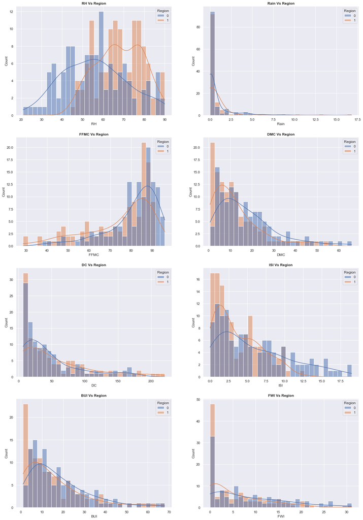

```python
plt.figure(figsize=(20,30))
for i in enumerate(continuous_features):
    plt.subplot(4, 2, i[0]+1)
    sns.set(rc={'figure.figsize':(7,7)})
    sns.histplot(data=df, x=i[1], kde=True, bins=30, color='blue', hue='Region')
    plt.title("{} Vs Region".format(i[1]),fontweight="bold")
```

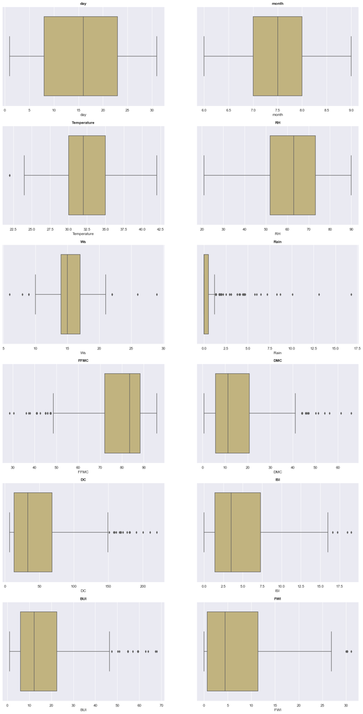

```python
### Checking outliers in numerical features

plt.figure(figsize=(20,40))
for i in enumerate(numerical_features):
    plt.subplot(6, 2, i[0]+1)
    sns.set(rc={'figure.figsize':(7,7)})
    sns.boxplot(data=df, x=i[1], color='y')
    plt.title("{}".format(i[1]), fontweight="bold")
```

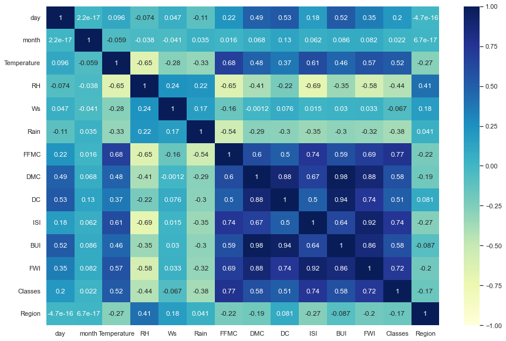

```python
### Plotting heatmap for visualising the correlation between features
sns.set(rc={'figure.figsize':(15,10)})
sns.heatmap(data=df.corr(), annot=True,  vmin=-1, vmax=1, cmap="YlGnBu")
```

```python
num_feature_custom= [feature for feature in numerical_features if feature not in ['day', 'month']]
num_feature_custom
```

```
['Temperature', 'RH', 'Ws', 'Rain', 'FFMC', 'DMC', 'DC', 'ISI', 'BUI', 'FWI']
```

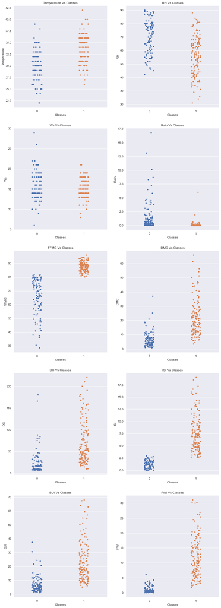

```python
plt.figure(figsize=(14,50))
for i in enumerate(num_feature_custom):
    plt.subplot(6, 2, i[0]+1)
    sns.set(rc={'figure.figsize':(7,8)})
    sns.stripplot(data=df, y=i[1], x='Classes')
    plt.title("{} Vs Classes".format(i[1]))
```

**Conclusion :**

- It is visible that for temperature between 30 to 37, there is most no of cases of occurance of fire, i.e Hot regions are more prone to forrest fires.
- For RH 40 to 70 and wind speed between 13 to 19 Km/h, Most no of cases of occurance of fire is reported, i.e dry regions are more prone to forrest fires.
- Almost all cases of occurance of fire is for region having rain less than 1 mm, i.e dry regions are more prone to forrest fires.
- For FFMC(Fine Fuel Moisture Code ) greater than 80, almost all cases of fire is reported.
- DMC (Duff Moisture Code) >30 and DC (Drought code) >100, almost all cases of occurance of fire reported, this means drought affected areas are more prone to forrest fires.

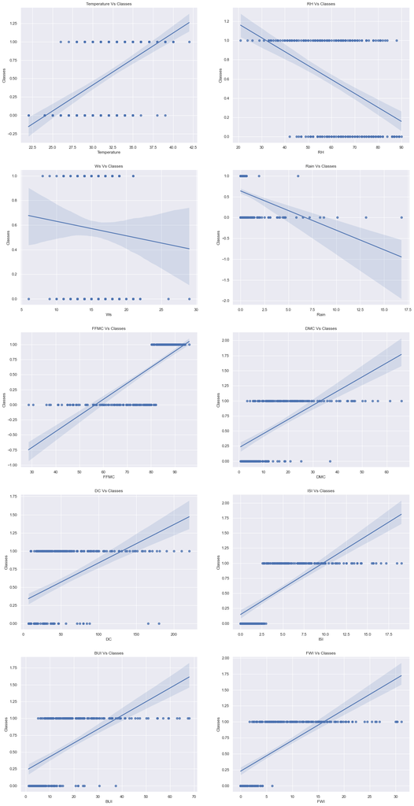

```python
plt.figure(figsize=(20,50))
for i in enumerate(num_feature_custom):
    plt.subplot(6, 2, i[0]+1)
    sns.set(rc={'figure.figsize':(8,10)})
    sns.regplot(data=df, x=i[1], y='Classes')
    plt.xlabel(i[1])
    plt.ylabel("Classes")
    plt.title("{} Vs Classes".format(i[1]))
```

**Conclusion :**

1. Very highly Correlated features: DMC-BUI, DC-BUI, ISI-FWI
2. Highly correlated features: FFMC-ISI, DC-DMC, FWI-DMC, FWI-DC, FWI-BUI
3. Temperature between 30 to 37 degree celcius have most no of cases of occurance of fire.
4. Wind speed between 13 to 19 Km/hr range there is most no of occurance of fire.
5. Almost all cases of occurance of fire is for region having rain less than 1 mm, i.e dry regions are more prone to forrest fires.
6. For FFMC(Fine Fuel Moisture Code ) greater than 80, almost all cases of fire is reported.
7. DMC (Duff Moisture Code) >30 and DC (Drought code) >100, almost all cases of occurance of fire reported, this means drought affected areas are more prone to forrest fires.
8. In Bejaia region, the no of cases of occurance of fire is less compared to no of cases of occurance of no fire.
9. In Sidi Bel-abbes region the no of cases of occurance of fire is more compared to no fire.
10. Also Overall no of cases of occurance of fire is more in Sidi Bel-abbes region as compared to Bejaia region.
11. Most no of cases of fire occured are in the month of august and least no of cases of fire occured is in month of september.
12. July and august have more cases of fire as compared to no fire.
13. June and september have more cases of no fire as compared to fire.
14. Relative Humidity, RH feature doesnt have outliers whereas Temperature, FFMC, wind speed, Rain, DMC,DC, ISI, BUI and FWI have outilers.
15. There is no null vales in dataset.

```python
x_col = ['day', 'month','Temperature','RH', 'Ws', 'Rain', 'FFMC',
        'ISI', 'BUI', 'FWI', 'Region']
print("x columns :", x_col)
print()

y_col = ['Classes']
print("x columns :", y_col)
```

```
x columns : ['day', 'month', 'Temperature', 'RH', 'Ws', 'Rain', 'FFMC', 'ISI', 'BUI', 'FWI', 'Region']

x columns : ['Classes']
```

```python
X = df[x_col]
X.head()
```

|  | day | month | Temperature | RH | Ws | Rain | FFMC | ISI | BUI | FWI | Region |
| --- | --- | --- | --- | --- | --- | --- | --- | --- | --- | --- | --- |
| 0 | 1 | 6 | 29 | 57 | 18 | 0.0 | 65.7 | 1.3 | 3.4 | 0.5 | 1 |
| 1 | 2 | 6 | 29 | 61 | 13 | 1.3 | 64.4 | 1.0 | 3.9 | 0.4 | 1 |
| 2 | 3 | 6 | 26 | 82 | 22 | 13.1 | 47.1 | 0.3 | 2.7 | 0.1 | 1 |
| 3 | 4 | 6 | 25 | 89 | 13 | 2.5 | 28.6 | 0.0 | 1.7 | 0.0 | 1 |
| 4 | 5 | 6 | 27 | 77 | 16 | 0.0 | 64.8 | 1.2 | 3.9 | 0.5 | 1 |

```python
y = df['Classes']
y.head()
```

```
0    0
1    0
2    0
3    0
4    0
Name: Classes, dtype: int32
```

## Fitting the Logistic Regression for Balanced Data

```python
# Machine Learning Libraries
from sklearn.model_selection import train_test_split
from sklearn.preprocessing import StandardScaler
from sklearn.linear_model import LogisticRegression
from sklearn.metrics import accuracy_score,confusion_matrix,f1_score,classification_report
```

```python
# data splitting
X_train, X_test, y_train, y_test = train_test_split(X,
                                                    y,
                                                    test_size= 0.25,
                                                    random_state= 42)
```

```python
X_train
```

|  | day | month | Temperature | RH | Ws | Rain | FFMC | ISI | BUI | FWI | Region |
| --- | --- | --- | --- | --- | --- | --- | --- | --- | --- | --- | --- |
| 115 | 24 | 9 | 29 | 65 | 19 | 0.6 | 68.3 | 1.5 | 5.8 | 0.7 | 1 |
| 181 | 30 | 7 | 36 | 56 | 16 | 0.0 | 88.9 | 8.2 | 23.8 | 13.2 | 0 |
| 225 | 12 | 9 | 31 | 72 | 14 | 0.0 | 84.2 | 3.8 | 9.1 | 3.9 | 0 |
| 68 | 8 | 8 | 32 | 60 | 18 | 0.3 | 77.1 | 2.2 | 14.1 | 2.6 | 1 |
| 104 | 13 | 9 | 25 | 86 | 21 | 4.6 | 40.9 | 0.1 | 1.8 | 0.0 | 1 |
| ... | ... | ... | ... | ... | ... | ... | ... | ... | ... | ... | ... |
| 106 | 15 | 9 | 24 | 82 | 15 | 0.4 | 44.9 | 0.2 | 1.4 | 0.0 | 1 |
| 14 | 15 | 6 | 28 | 80 | 17 | 3.1 | 49.4 | 0.4 | 3.0 | 0.1 | 1 |
| 92 | 1 | 9 | 25 | 76 | 17 | 7.2 | 46.0 | 0.2 | 1.8 | 0.1 | 1 |
| 179 | 28 | 7 | 33 | 57 | 16 | 0.0 | 87.5 | 6.7 | 15.7 | 9.0 | 0 |
| 102 | 11 | 9 | 30 | 77 | 21 | 1.8 | 58.5 | 1.1 | 2.4 | 0.3 | 1 |

183 rows × 11 columns

```python
# Creating a standard scaler object
scaler= StandardScaler()
scaler
```

```
StandardScaler()
```

```python
# Using fit_transform to Standardize the train data
X_train= scaler.fit_transform(X_train)
X_train
```

```
array([[ 0.93609743,  1.35196693, -0.81085018, ..., -0.7596667 ,
        -0.85129015,  1.00547949],
       [ 1.61141607, -0.44085878,  1.06405791, ...,  0.49583584,
         0.85151347, -0.99455037],
       [-0.41453986,  1.35196693, -0.27516216, ..., -0.52949124,
        -0.41537243, -0.99455037],
       ...,
       [-1.65262404,  1.35196693, -1.88222624, ..., -1.03866727,
        -0.93302473,  1.00547949],
       [ 1.38630986, -0.44085878,  0.26052587, ..., -0.0691403 ,
         0.27937145, -0.99455037],
       [-0.52709297,  1.35196693, -0.54300617, ..., -0.99681719,
        -0.90577987,  1.00547949]])
```

```python
X_test= scaler.transform(X_test)
```

```python
# Fit the logistic regression
log_reg= LogisticRegression(random_state=0)
log_reg
```

```
LogisticRegression(random_state=0)
```

```python
log_reg.fit(X_train, y_train)
```

```
LogisticRegression(random_state=0)
```

```python
# Predict the model
lg_prd= log_reg.predict(X_test)
lg_prd
```

```
array([1, 1, 1, 1, 1, 0, 1, 0, 0, 0, 0, 0, 0, 0, 1, 1, 1, 0, 1, 1, 0, 0,
       1, 0, 1, 0, 1, 1, 0, 1, 1, 0, 1, 1, 0, 0, 0, 1, 0, 0, 1, 1, 0, 0,
       1, 1, 1, 0, 1, 1, 1, 0, 1, 1, 1, 1, 1, 0, 0, 1, 1])
```

```python
# Confusion Matrix
cm= confusion_matrix(y_test,lg_prd)
cm
```

```
array([[24,  0],
       [ 2, 35]], dtype=int64)
```

```python
tp = cm[0][0]
fp = cm[0][1]
fn = cm[1][0]
tn = cm[1][1]

print("True Positive :", tp, '\n',
      "False Positive :", fp, '\n',
      "False Negative :", fn, '\n',
      "True Negative :", tn)
```

```
True Positive : 24
 False Positive : 0
 False Negative : 2
 True Negative : 35
```

```python
# Accuracy Score
accuracy= round(accuracy_score(y_test, lg_prd),4)
accuracy
```

```
0.9672
```

The **Accuracy** of Our Model is $0.9672$ or Our Model is $96.7\%$ correct.

```python
# Precision of Our Model
precision_manual= round(tp/(tp+fp), 4)

print("Precision of our model is ", precision_manual)
```

```
Precision of our model is  1.0
```

```python
# Recall of Our Model
recall_manual= round(tp/(tp+fn), 4)

print("Recall of our model is ", recall_manual)
```

```
Recall of our model is  0.9231
```

```python
# F1 Score of Our Model
f1_score= 2*(precision_manual*recall_manual)/(precision_manual+recall_manual)
print("F-1 Score of our model is ", round(f1_score,4))
```

```
F-1 Score of our model is  0.96
```

```python
# Classification Report
print(classification_report(y_test, lg_prd))
```

```
              precision    recall  f1-score   support

           0       0.92      1.00      0.96        24
           1       1.00      0.95      0.97        37

    accuracy                           0.97        61
   macro avg       0.96      0.97      0.97        61
weighted avg       0.97      0.97      0.97        61
```

```python
from sklearn.metrics import roc_curve, roc_auc_score
```

```python
# Area Under Curve (AUC)
auc = roc_auc_score(y_test, lg_prd)
auc
```

```
0.972972972972973
```